# Do molecular biomarkers improve brain cancer prediction?

Sukhman Parhar & Lawrence Zicari

2026-04-23

### Project Description - Option 3

Project Members - Lawrence Zicari & Sukhman Parhar

Dataset - SEER (Surveillance, Epidemiology, and End Results) Program - National Cancer Incidence Dataset (2018+ Biomarker Cohort)

Research Question - Do molecular biomarkers improve the predictive performance of models identifying high-risk brain cancer patients (survival <1 year) compared to models using clinical variables alone?

This is a predictive question with the goal of improving classification of patients into “high-risk” and “low-risk” categories.

### Rationale

Brain cancer remains a highly lethal diagnosis and early identification of high-risk patients is critical for improving outcomes and developing treatment plans. While traditional clinical variables (age, tumor stage, grade…) are important, they can fail to capture some of the more complex biological signals in cancer cases.

Advances in precision medicine have explored molecular biomarkers that provide more specific and deeper insights into tumors. SEER began collected data on these biomarkers in 2018 creating an opportunity to assess if these features significantly improve predictive power of high risk patients. In this study, we define high risk as survival less than 12 months. This is a commonly used clinical threshold for identifying highly aggressive cancer diasgnoses and is essential for guiding early interventions. This study aims to determine if precision medicine features can better identify high-risk patients allowing for more individualized treatment strategies.

### Analytic Pipeline Summary

Data Preparation: Cleaning, handling of missingness, and labeling of variables

Construction of new variable: Run a PCA to create a treatment intensity index variable

Data Partition & Cross validation set up: 80/20 train/test split with a 10-fold cross validation will be implemented

Model Training: 3 algorithms will be used for comparisons and each will have their given hyperparameters tuned Elastic Net - Baseline model with lower complexity that can also assist in feature selection Random Forest - Handles any non-linear relationships and interaction while allowing for the direct assessment of variable importance Boosting - Optimize predictive accuracy

Model Comparison: Area Under the Curve will be used to determine the model with the strongest predictive performance. This model will then be tested on the test set to evaluate final performance.

### Loading Data

```r
data <- read_delim("SEER_brain_full.txt",
                    delim = "\t",
                    escape_double = FALSE,
                    trim_ws = TRUE) %>%
  clean_names()
```

### Cleaning Pipeline

```r
df_clean <- data

# BASIC NUMERIC CLEANING

df_clean <- df_clean %>%
  mutate(
    survival_months = suppressWarnings(as.numeric(survival_months)),
    time_from_diagnosis_to_treatment_in_days_recode =
      suppressWarnings(as.numeric(time_from_diagnosis_to_treatment_in_days_recode)),
    year_of_diagnosis = suppressWarnings(as.numeric(year_of_diagnosis)),
    tumor_size_summary_2016 = suppressWarnings(as.numeric(tumor_size_summary_2016)),
    regional_nodes_examined_1988 =
      suppressWarnings(as.numeric(regional_nodes_examined_1988)),
    regional_nodes_positive_1988 =
      suppressWarnings(as.numeric(regional_nodes_positive_1988))
  )

# Clean missing - Standardizing missing into NA per SEER data dictionary codes

df_clean <- df_clean %>%
  mutate(
    # survival_months: 9999 means unknown
    survival_months = ifelse(survival_months >= 9999, NA, survival_months),

    # time_to_treatment: 999 means unknown
    time_from_diagnosis_to_treatment_in_days_recode =
      na_if(time_from_diagnosis_to_treatment_in_days_recode, 999),

    # tumor_size_summary_2016 uses 999 as unknown
    tumor_size_summary_2016 = na_if(tumor_size_summary_2016, 999),

    # nodes uses 99 as unknown
    regional_nodes_examined_1988 = na_if(regional_nodes_examined_1988, 99),
    regional_nodes_positive_1988 = na_if(regional_nodes_positive_1988, 99)
  ) %>%
  mutate(
    across(
      c(
        race_recode_white_black_other,
        radiation_recode,
        rx_summ_surg_rad_seq,
        rx_summ_systemic_sur_seq_2007,
        reason_no_cancer_directed_surgery,
        diagnostic_confirmation,
        combined_summary_stage_with_expanded_regional_codes_2004,
        grade_clinical_2018,
        grade_pathological_2018,
        marital_status_at_diagnosis
      ),
      ~ na_if(., 9)
    )
  ) %>%
  mutate(
    across(
      c(
        brain_molecular_markers_2018,
        median_household_income_inflation_adj_to_2023,
        rural_urban_continuum_code
      ),
      ~ na_if(., 99)
    )
  ) %>%
  mutate(
    brain_molecular_markers_2018 = na_if(brain_molecular_markers_2018, 126)
  )

# Check with survival flag
# SURVIVAL OUTCOME VARIABLES
df_clean <- df_clean %>%
  mutate(
    time = survival_months,
    event = case_when(
      vital_status_recode_study_cutoff_used == 1 ~ 1,
      vital_status_recode_study_cutoff_used == 0 ~ 0,
      TRUE ~ NA_real_
    )
  )

# Age factor & labeling
df_clean <- df_clean %>%
  mutate(
    age_factor = factor(
      age_recode_with_1_year_olds_and_90,
      levels = 0:19,
      ordered = TRUE
    ) %>%
      fct_recode(
        "00 years" = "0",
        "01-04 years" = "1",
        "05-09 years" = "2",
        "10-14 years" = "3",
        "15-19 years" = "4",
        "20-24 years" = "5",
        "25-29 years" = "6",
        "30-34 years" = "7",
        "35-39 years" = "8",
        "40-44 years" = "9",
        "45-49 years" = "10",
        "50-54 years" = "11",
        "55-59 years" = "12",
        "60-64 years" = "13",
        "65-69 years" = "14",
        "70-74 years" = "15",
        "75-79 years" = "16",
        "80-84 years" = "17",
        "85-89 years" = "18",
        "90+ years" = "19"
      )
  )


# Demographic variable factoring  & labeling
df_clean <- df_clean %>%
  mutate(
    race_factor = factor(race_recode_white_black_other) %>%
      fct_recode(
        "White" = "1",
        "Black" = "2",
        "Other" = "3"
      ) %>%
      fct_na_value_to_level(level = "Unknown"),

    sex_factor = factor(sex) %>%
      fct_recode(
        "Male" = "1",
        "Female" = "2"
      ) %>%
      fct_na_value_to_level(level = "Unknown"),

    marital_status_factor = factor(marital_status_at_diagnosis) %>%
      fct_recode(
        "Single" = "1",
        "Married" = "2",
        "Separated" = "3",
        "Divorced" = "4",
        "Widowed" = "5",
        "Unmarried or Domestic Partner" = "6"
      ) %>%
      fct_na_value_to_level(level = "Unknown")
  )


# Treatment variable factoring  & labeling

df_clean <- df_clean %>%
  mutate(
    radiation_factor = factor(radiation_recode) %>%
      fct_recode(
        "None" = "0",
        "Beam Radiation" = "1",
        "Radioactive Implants" = "2",
        "Radioisotopes" = "5",
        "Refused" = "7",
        "Recommended, Unknown if Given" = "8"
      ) %>%
      fct_na_value_to_level(level = "Unknown"),

    radiation_binary = case_when(
      radiation_recode == 1 ~ "Yes",
      radiation_recode %in% c(0, 2, 5, 7, 8) ~ "No/Other",
      TRUE ~ "Unknown"
    ),
    radiation_binary = factor(radiation_binary,
                              levels = c("No/Other", "Yes", "Unknown")),

    chemo_factor = factor(chemotherapy_recode_yes_no_unk) %>%
      fct_recode(
        "No/Unknown" = "0",
        "Yes" = "1"
      ) %>%
      fct_na_value_to_level(level = "Unknown"),

    surgery_performed = case_when(
      reason_no_cancer_directed_surgery == 0 ~ "Surgery Performed",
      reason_no_cancer_directed_surgery %in% c(1, 2, 5, 6, 7, 8) ~ "No Surgery",
      TRUE ~ "Unknown"
    ),
    surgery_performed = factor(
      surgery_performed,
      levels = c("Surgery Performed", "No Surgery", "Unknown")
    ),

    surgery_sequence_factor = factor(rx_summ_surg_rad_seq) %>%
      fct_recode(
        "No Radiation and/or No Surgery" = "0",
        "Radiation Before Surgery" = "2",
        "Radiation After Surgery" = "3",
        "Intraoperative Radiation" = "4",
        "Intraoperative + Other Radiation" = "5",
        "Surgery Both Before and After Radiation" = "6"
      ) %>%
      fct_na_value_to_level(level = "Unknown"),

    systemic_sequence_factor = factor(rx_summ_systemic_sur_seq_2007) %>%
      fct_recode(
        "No Systemic Therapy and/or No Surgery" = "0",
        "Systemic Therapy Before Surgery" = "2",
        "Systemic Therapy After Surgery" = "3",
        "Systemic Therapy Both Before and After Surgery" = "4"
      ) %>%
      fct_na_value_to_level(level = "Unknown")
  )


# Tumor / disease factoring  & labeling

df_clean <- df_clean %>%
  mutate(
    stage_factor = factor(combined_summary_stage_with_expanded_regional_codes_2004) %>%
      fct_recode(
        "Localized" = "1",
        "Regional" = "2",
        "Distant" = "7",
        "Benign" = "8"
      ) %>%
      fct_na_value_to_level(level = "Unknown"),
```

```r
    diagnostic_confirmation_factor = factor(diagnostic_confirmation) %>%
      fct_recode(
        "Positive Histology" = "1",
        "Positive Cytology" = "2",
        "Positive Laboratory Test/Marker Study" = "4",
        "Direct Visualization without Microscopic Confirmation" = "5",
        "Radiography without Microscopic Confirmation" = "6",
        "Clinical Diagnosis Only" = "7",
        "Unknown" = "8"
      ) %>%
      fct_na_value_to_level(level = "Unknown"),

    histology_factor = factor(histology_recode_broad_groupings) %>%
      fct_collapse(
        "Glioma" = c("35"),
        "Germ Cell Neoplasm" = c("25"),
        "Neuroepitheliomatous Neoplasm" = c("36"),
        "Fibromatous Neoplasm" = c("17"),
        "Other Malignant" = c("0", "2", "15", "16", "20", "21", "28", "30", "32", "34", "38")
      ) %>%
      fct_na_value_to_level(level = "Unknown"),

    primary_site_factor = factor(primary_site_labeled) %>%
      fct_recode(
        "Cerebrum NOS" = "710",
        "Frontal Lobe" = "711",
        "Temporal Lobe" = "712",
        "Parietal Lobe" = "713",
        "Occipital Lobe" = "714",
        "Ventricle" = "715",
        "Cerebellum" = "716",
        "Brain Stem" = "717",
        "Overlapping Lesion of Brain" = "718",
        "Brain NOS" = "719"
      ) %>%
      fct_na_value_to_level(level = "Unknown")
  )


# Tumor Grade Classification - 2 variables indicate grade, the main being "grade_pathological" but if missing, we assess grade via "grade_clinical" to maximize data retention. Using standard defintions, we then collapsed grade into a binary Low Grade/High Grade variable.

df_clean <- df_clean %>%
  mutate(
    grade_combined_raw = coalesce(grade_pathological_2018, grade_clinical_2018),

    grade_factor = factor(grade_combined_raw) %>%
      fct_recode(
        "Grade I" = "1",
        "Grade II" = "2",
        "Grade III" = "3",
        "Grade IV" = "4",
        "Cell Type Not Determined, Not Stated or Not Applicable" = "9"
      ) %>%
      fct_na_value_to_level(level = "Unknown"),

    grade_binary = case_when(
      grade_combined_raw %in% c(1, 2, 15) ~ "Low Grade",
      grade_combined_raw %in% c(3, 4, 16) ~ "High Grade",
      TRUE ~ "Unknown"
    ),
    grade_binary = factor(grade_binary,
                          levels = c("Low Grade", "High Grade", "Unknown"))
  )


# Molecular Markers - re-coded into 5 distinct biological groupings

df_clean <- df_clean %>%
  mutate(
    molecular_factor = factor(brain_molecular_markers_2018) %>%
      fct_recode(
        "Astrocytoma, IDH-mutant, Grade II" = "1",
        "Astrocytoma, IDH-wildtype, Grade II" = "2",
        "Astrocytoma, IDH-mutant, Grade III" = "3",
        "Astrocytoma, IDH-wildtype, Grade III" = "4",
        "Glioblastoma, IDH-wildtype" = "5",
        "Oligodendroglioma, IDH-mutant and 1p/19q-codeleted" = "6",
        "Oligodendroglioma, Grade III, IDH-mutant and 1p/19q-codeleted" = "7",
        "Medulloblastoma / Other" = "8",
        "Embryonal / Other" = "9",
        "Not Applicable" = "85",
        "Test Ordered, Results Not in Chart" = "87"
      ) %>%
      fct_na_value_to_level(level = "Unknown"),

    molecular_collapsed = case_when(
      brain_molecular_markers_2018 %in% c(1, 3) ~ "Astrocytoma IDH-mutant",
      brain_molecular_markers_2018 %in% c(2, 4, 5) ~ "IDH-wildtype",
      brain_molecular_markers_2018 %in% c(6, 7) ~ "Oligodendroglioma IDH-mutant 1p19q-codeleted",
      brain_molecular_markers_2018 %in% c(8, 9) ~ "Other Molecular Group",
      brain_molecular_markers_2018 %in% c(85, 87) ~ "Not Applicable/Pending",
      is.na(brain_molecular_markers_2018) ~ "Unknown",
      TRUE ~ "Unknown"
    ),
    molecular_collapsed = factor(
      molecular_collapsed,
      levels = c(
        "Astrocytoma IDH-mutant",
        "IDH-wildtype",
        "Oligodendroglioma IDH-mutant 1p19q-codeleted",
        "Other Molecular Group",
        "Not Applicable/Pending",
        "Unknown"
      )
    )
  )


# Socioeconomic and geographic variable factoring & labeling

df_clean <- df_clean %>%
  mutate(
    income_factor = factor(median_household_income_inflation_adj_to_2023) %>%
      fct_recode(
        "<$35,000" = "1",
        "$35,000-$39,999" = "2",
        "$40,000-$44,999" = "3",
        "$45,000-$49,999" = "4",
        "$50,000-$54,999" = "5",
        "$55,000-$59,999" = "6",
        "$60,000-$64,999" = "7",
        "$65,000-$69,999" = "8",
        "$70,000-$74,999" = "9",
        "$75,000+" = "10"
      ) %>%
      fct_na_value_to_level(level = "Unknown"),

    # Creating binary income variable
    income_binary = case_when(
      median_household_income_inflation_adj_to_2023 %in% 1:9 ~ "<$75,000",
      median_household_income_inflation_adj_to_2023 == 10 ~ "$75,000+",
      TRUE ~ "Unknown"
    ),
    income_binary = factor(income_binary,
                           levels = c("<$75,000", "$75,000+", "Unknown")),

    # Creating rurality binary variable (metropolitan vs non-metropolitan)
    rurality_factor = factor(rural_urban_continuum_code) %>%
      fct_recode(
        "Metro 1M+" = "1",
        "Metro 250K-1M" = "2",
        "Metro <250K" = "3",
        "Urban Adjacent" = "4",
        "Urban Nonadjacent" = "5",
        "Rural Adjacent" = "6",
        "Rural Nonadjacent" = "7",
        "Completely Rural or <2,500 Urban Population, Adjacent" = "8",
        "Completely Rural or <2,500 Urban Population, Nonadjacent" = "9"
      ) %>%
      fct_na_value_to_level(level = "Unknown"),

    rurality_binary = case_when(
      rural_urban_continuum_code %in% c(1, 2, 3) ~ "Metropolitan",
      rural_urban_continuum_code %in% c(4, 5, 6, 7, 8, 9) ~ "Non-metropolitan",
      TRUE ~ "Unknown"
    ),
    rurality_binary = factor(rurality_binary,
                             levels = c("Metropolitan", "Non-metropolitan", "Unknown"))
  )


# Descrptive labels for variables

df_clean <- set_variable_labels(
  df_clean,
  age_factor = "Age at diagnosis",
  #age_group_collapsed = "Collapsed age group",
  race_factor = "Race",
  sex_factor = "Sex",
  marital_status_factor = "Marital status at diagnosis",
  year_of_diagnosis = "Year of diagnosis",
  radiation_factor = "Radiation recode",
  radiation_binary = "Radiation yes/no",
  chemo_factor = "Chemotherapy recode",
  surgery_performed = "Cancer-directed surgery performed",
  surgery_sequence_factor = "Surgery/radiation sequence",
  systemic_sequence_factor = "Systemic therapy/surgery sequence",
  income_factor = "Median household income, inflation adjusted to 2023",
  income_binary = "Income binary",
  rurality_factor = "Rural-Urban Continuum Code",
  rurality_binary = "Rurality binary",
  time = "Survival time in months",
  event = "Death indicator",
  seer_cause_specific_death_classification = "SEER cause-specific death classification",
  molecular_factor = "Brain molecular markers (2018+)",
  molecular_collapsed = "Collapsed molecular marker group",
  diagnostic_confirmation_factor = "Diagnostic confirmation",
  stage_factor = "Combined summary stage",
  grade_factor = "Tumor grade",
  grade_binary = "Tumor grade binary",
  histology_factor = "Histology broad grouping",
  primary_site_factor = "Primary site",
  tumor_size_summary_2016 = "Tumor size summary",
  regional_nodes_examined_1988 = "Regional nodes examined",
  regional_nodes_positive_1988 = "Regional nodes positive"
)
```

```r
# Dropping old variables
df_clean <- df_clean %>%
   select(
     -age_recode_with_1_year_olds_and_90,
     -race_recode_white_black_other,
     -sex,
     -radiation_recode,
     -chemotherapy_recode_yes_no_unk,
     -reason_no_cancer_directed_surgery,
     -rx_summ_surg_rad_seq,
     -rx_summ_systemic_sur_seq_2007,
     -brain_molecular_markers_2018,
     -diagnostic_confirmation,
     -combined_summary_stage_with_expanded_regional_codes_2004,
     -grade_clinical_2018,
     -grade_pathological_2018,
     -histology_recode_broad_groupings,
     -primary_site_labeled,
     -median_household_income_inflation_adj_to_2023,
     -rural_urban_continuum_code,
     -marital_status_at_diagnosis
   )


# Analysis ready dataset

analysis_df <- df_clean %>%
  filter(!is.na(time), time > 0) %>%
  filter(!is.na(event))


# Checks to ensure successful cleaning pipeline

str(df_clean)

table(df_clean$age_factor, useNA = "ifany")
table(df_clean$race_factor, useNA = "ifany")
table(df_clean$sex_factor, useNA = "ifany")
table(df_clean$stage_factor, useNA = "ifany")
table(df_clean$grade_factor, useNA = "ifany")
table(df_clean$grade_binary, useNA = "ifany")
table(df_clean$molecular_factor, useNA = "ifany")
table(df_clean$molecular_collapsed, useNA = "ifany")
table(df_clean$radiation_factor, useNA = "ifany")
table(df_clean$chemo_factor, useNA = "ifany")
table(df_clean$surgery_performed, useNA = "ifany")
summary(df_clean$time)
table(df_clean$event, useNA = "ifany")

df_ml <- df_clean %>%
  mutate(stage_binary = ifelse(stage_factor == "Localized", "Localized", "Advanced"),
         stage_binary = factor(stage_binary))

df_ml <- df_ml %>%
  filter(!molecular_collapsed %in% c("Unknown", "Not Applicable/Pending")) %>%
  droplevels()

df_ml <- df_ml %>%
  filter(!is.na(time))

df_ml <- df_ml %>%
  mutate(
    sex_factor = factor(sex_factor),
    race_factor = factor(race_factor),
    stage_factor = factor(stage_factor),
    radiation_binary = factor(radiation_binary),
    chemo_factor = factor(chemo_factor),
    surgery_performed = factor(surgery_performed),
    income_binary = factor(income_binary),
    rurality_binary = factor(rurality_binary)
  )

summary(df_ml)
sapply(df_ml, function(x) sum(is.na(x)))

## Creating binary outcome variable for models
df_ml <- df_ml %>%
  mutate(event_factor = factor(ifelse(event == 1, "Death", "Alive"),
                               levels = c("Death", "Alive")))

table(df_ml$event_factor)

# creating high-risk outcome variable for models
df_ml <- df_ml %>%
  mutate(high_risk = ifelse(time < 12, "HighRisk", "LowRisk"),
         high_risk = factor(high_risk, levels = c("HighRisk", "LowRisk")))

table(df_ml$high_risk)
```

This cleaning pipeline handled missingness by standardizing variable specific unknown codes to NA values. Categorical variables including demographics, clinical staging, and biomarkers were re-coded and factored into clinically meaningful groups and variables were labeled to ensure readability. A binary outcome variable was also created to assess risk with a 12 month survival threshold to define low or high risk patients.

### Descriptive Statistics - Table 1

```r
df_ml %>%
  select(
    high_risk,
    age_factor,
    sex_factor,
    race_factor,
    grade_binary,
    molecular_collapsed,
    chemo_factor,
    radiation_binary,
    surgery_performed
  ) %>%
  tbl_summary(
    by = high_risk,
    label = list(
      age_factor ~ "Age at Diagnosis",
      sex_factor ~ "Sex",
      race_factor ~ "Race",
      grade_binary ~ "Tumor Grade",
      molecular_collapsed ~ "Molecular Biomarker",
      chemo_factor ~ "Chemotherapy Received",
      radiation_binary ~ "Radiation Received",
      surgery_performed ~ "Cancer-Directed Surgery"
    )
  ) %>%
  add_p(
    test = list(all_categorical() ~ "fisher.test"),
    test.args = list(all_categorical() ~ list(simulate.p.value = TRUE))
  ) %>%
  bold_labels()
```

| **Characteristic** | **HighRisk** N = 3,367<sup>1</sup> | **LowRisk** N = 2,535<sup>1</sup> | **p-value**<sup>2</sup> |
| --- | --- | --- | --- |
| Age at Diagnosis |  |  | <0.001 |
| 00 years | 2 (<0.1%) | 4 (0.2%) |  |
| 01-04 years | 5 (0.1%) | 16 (0.6%) |  |
| 05-09 years | 4 (0.1%) | 9 (0.4%) |  |
| 10-14 years | 9 (0.3%) | 19 (0.7%) |  |
| 15-19 years | 17 (0.5%) | 33 (1.3%) |  |
| 20-24 years | 19 (0.6%) | 50 (2.0%) |  |
| 25-29 years | 41 (1.2%) | 111 (4.4%) |  |
| 30-34 years | 65 (1.9%) | 136 (5.4%) |  |
| 35-39 years | 80 (2.4%) | 158 (6.2%) |  |
| 40-44 years | 110 (3.3%) | 166 (6.5%) |  |
| 45-49 years | 128 (3.8%) | 185 (7.3%) |  |
| 50-54 years | 185 (5.5%) | 244 (9.6%) |  |
| 55-59 years | 311 (9.2%) | 323 (13%) |  |
| 60-64 years | 450 (13%) | 333 (13%) |  |
| 65-69 years | 536 (16%) | 301 (12%) |  |
| 70-74 years | 583 (17%) | 254 (10%) |  |
| 75-79 years | 436 (13%) | 128 (5.0%) |  |
| 80-84 years | 250 (7.4%) | 54 (2.1%) |  |
| 85-89 years | 115 (3.4%) | 8 (0.3%) |  |
| 90+ years | 21 (0.6%) | 3 (0.1%) |  |
| Sex |  |  | 0.024 |
| Male | 1,913 (57%) | 1,515 (60%) |  |
| Female | 1,454 (43%) | 1,020 (40%) |  |
| Race |  |  | 0.3 |
| White | 2,929 (87%) | 2,170 (86%) |  |
| Black | 184 (5.5%) | 138 (5.4%) |  |
| Other | 239 (7.1%) | 214 (8.4%) |  |
| Unknown | 15 (0.4%) | 13 (0.5%) |  |
| Tumor Grade |  |  | <0.001 |
| Low Grade | 158 (4.7%) | 418 (16%) |  |
| High Grade | 3,129 (93%) | 2,062 (81%) |  |
| Unknown | 80 (2.4%) | 55 (2.2%) |  |
| Molecular Biomarker |  |  | <0.001 |
| Astrocytoma IDH-mutant | 172 (5.1%) | 358 (14%) |  |
| IDH-wildtype | 3,061 (91%) | 1,803 (71%) |  |
| Oligodendroglioma IDH-mutant 1p19q-codeleted | 118 (3.5%) | 338 (13%) |  |
| Other Molecular Group | 16 (0.5%) | 36 (1.4%) |  |
| Chemotherapy Received |  |  | <0.001 |
| No/Unknown | 1,316 (39%) | 337 (13%) |  |
| Yes | 2,051 (61%) | 2,198 (87%) |  |
| Radiation Received |  |  | <0.001 |
| No/Other | 1,137 (34%) | 309 (12%) |  |
| Yes | 2,230 (66%) | 2,226 (88%) |  |
| Cancer-Directed Surgery |  |  | <0.001 |
| Surgery Performed | 2,689 (80%) | 2,295 (91%) |  |
| No Surgery | 676 (20%) | 240 (9.5%) |  |
| Unknown | 2 (<0.1%) | 0 (0%) |  |

<sup>1</sup> n (%)  
<sup>2</sup> Fisher’s Exact Test for Count Data with simulated p-value (based on 2000 replicates); Fisher’s exact test

# Analystic Pipeline

### Unsupervised Analysis (PCA) - Treatment Intensity Index variable

```r
## create numeric treatment variables
df_ml <- df_ml %>%
  mutate(
    chemo_num = ifelse(chemo_factor == "Yes", 1, 0),
    radiation_num = ifelse(radiation_binary == "Yes", 1, 0),
    surgery_num = ifelse(surgery_performed == "Surgery Performed", 1, 0)
  )

## PCA for treatment intensity
treatment_matrix <- df_ml %>%
  select(chemo_num, radiation_num, surgery_num) %>%
  as.matrix()

pca_treat <- prcomp(treatment_matrix, scale. = TRUE)

summary(pca_treat)
```

```
## Importance of components:
##                           PC1    PC2     PC3
## Standard deviation     1.3567 0.9773 0.45194
## Proportion of Variance 0.6135 0.3184 0.06808
## Cumulative Proportion  0.6135 0.9319 1.00000
```

```r
# Checking the loadings for the PCA
pca_treat$rotation
```

```
##                      PC1        PC2          PC3
## chemo_num     -0.6888568  0.1602702 -0.706958113
## radiation_num -0.6891138  0.1578445  0.707253345
## surgery_num   -0.2249411 -0.9743709 -0.001712183
```

```r
## add treatment intensity score (PC1)
df_ml$treatment_intensity <- pca_treat$x[,1]

summary(df_ml$treatment_intensity)
```

```
##    Min. 1st Qu.  Median    Mean 3rd Qu.    Max.
## -0.9187 -0.9187 -0.9187  0.0000  0.6835  2.8380
```

PC1 explains 61.4% of the total variance in the treatment variables and is the most efficient single-variable index of treatment intensity. The loadings of the PC1 indicate that chemotherapy (-0.689) and radiation (-0.689) are the primary drivers of the index while surgery (-0.225) contributes to a lesser degree. Because all the loadings were negative, a lower score of PC1 actually indicates a more intense treatment received. This new variable allows the predictive models to account for the synergistic effects of the combined treatment therapies while reducing the risk of over-fitting by decreasing the amount of features.

### Defining our Models: Model A - No molecular biomarkers ; Model B - With moelcular biomarkers

To evaluate the predictive value of the molecular biomarker features, we constructed two distinct models. Model A is the baseline using traditional demographic and clinical variables. Model B includes the same features with the addition of the biomarker variable. This approach will allow for the direct comparison of performance metrics across our selected algorithms. Only patients with complete data regarding the selected clinical and biomarker variables were included in the analysis to avoid any biases associated with estimating unknown clinical data.

```r
## Model A dataset (no biomarkers)
df_model_A <- df_ml %>%
  select(
    high_risk,
    age_factor,
    sex_factor,
    race_factor,
    stage_binary,
    grade_binary,
    treatment_intensity
  ) %>%
  na.omit() %>%
  droplevels()

## Model B dataset (WITH biomarkers)
df_model_B <- df_ml %>%
  select(
    high_risk,
    age_factor,
    sex_factor,
    race_factor,
    stage_binary,
    grade_binary,
    treatment_intensity,
    molecular_collapsed
  ) %>%
  na.omit() %>%
  droplevels()
```

### Data partitioning & CV set up - 80/20 train/test split Create the split and 10-fold CV

```r
# Data partition
set.seed(2)

# split Model A
split_A <- initial_split(df_model_A, prop = 0.8, strata = high_risk)

train_A <- training(split_A)
test_A  <- testing(split_A)

# split Model B
split_B <- initial_split(df_model_B, prop = 0.8, strata = high_risk)

train_B <- training(split_B)
test_B  <- testing(split_B)

# set up cross validation
ctrl <- trainControl(method = "cv", number = 10,
                     summaryFunction = twoClassSummary,
                     classProbs = TRUE)
```

An 80/20 training/test partition was established to test the final model on unseen data to see how it performs on new patients. A 10-fold cross-validation was established to ensure model stability and robustness of performance metrics during the training phase to optimize hyperparameter tuning and reduce the potential for overfitting.

### Algorithm 1 - Elastic Net

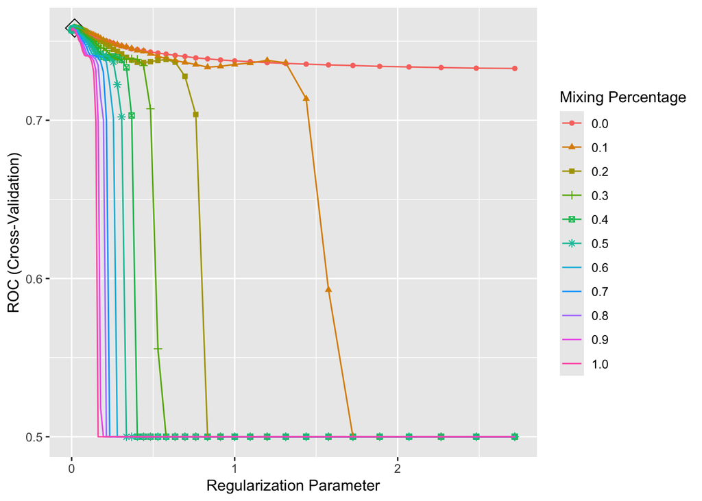

```r
# Model A
set.seed(2)

en.grid <- expand.grid(
  alpha = seq(0, 1, length = 11),
  lambda = exp(seq(-8, 1, length = 100))
)

en_A.fit <- train(
  high_risk ~ .,
  data = train_A,
  method = "glmnet",
  tuneGrid = en.grid,
  trControl = ctrl,
  metric = "ROC"
)

ggplot(en_A.fit, highlight = TRUE)
```

```r
en_A.fit$bestTune
```

```
##     alpha     lambda
## 345   0.3 0.01831564
```

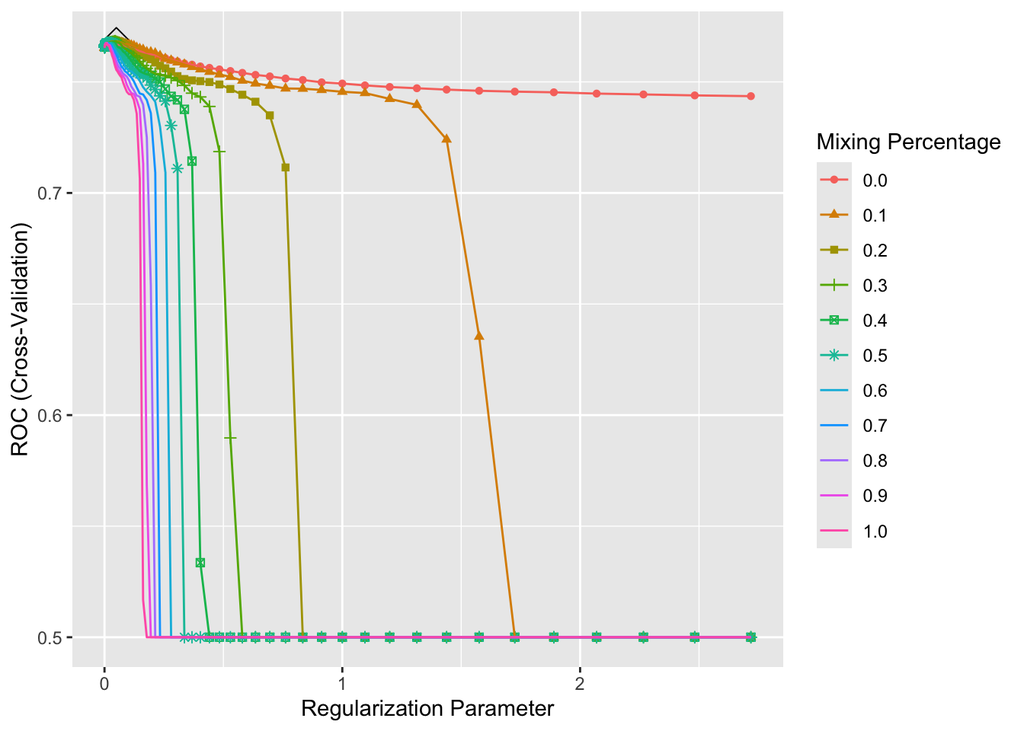

```r
# Model B
set.seed(2)

en_B.fit <- train(
  high_risk ~ .,
  data = train_B,
  method = "glmnet",
  tuneGrid = en.grid,
  trControl = ctrl,
  metric = "ROC"
)

ggplot(en_B.fit, highlight = TRUE)
```

```r
en_B.fit$bestTune
```

```
##     alpha     lambda
## 256   0.2 0.04978707
```

```r
## Evaluation on Training Data (Model A)
en_A_train_prob <- predict(en_A.fit, newdata = train_A, type = "prob")[, "HighRisk"]
en_A_train_pred <- predict(en_A.fit, newdata = train_A)

# Training Confusion Matrix
confusionMatrix(en_A_train_pred, train_A$high_risk)
```

```
## Confusion Matrix and Statistics
##
##           Reference
## Prediction HighRisk LowRisk
##   HighRisk     2052     817
##   LowRisk       641    1211
##
##                Accuracy : 0.6912
##                  95% CI : (0.6778, 0.7043)
##     No Information Rate : 0.5704
##     P-Value [Acc > NIR] : < 2.2e-16
##
##                   Kappa : 0.363
##
##  Mcnemar's Test P-Value : 4.581e-06
##
##             Sensitivity : 0.7620
##             Specificity : 0.5971
##          Pos Pred Value : 0.7152
##          Neg Pred Value : 0.6539
##              Prevalence : 0.5704
##          Detection Rate : 0.4347
##    Detection Prevalence : 0.6077
##       Balanced Accuracy : 0.6796
##
##        'Positive' Class : HighRisk
##
```

```r
# Training ROC/AUC
roc_en_A_train <- roc(train_A$high_risk, en_A_train_prob)
roc_en_A_train$auc
```

```
## Area under the curve: 0.7601
```

```r
## Evaluation on Training Data (Model B - WITH Biomarkers)
en_B_train_prob <- predict(en_B.fit, newdata = train_B, type = "prob")[, "HighRisk"]
en_B_train_pred <- predict(en_B.fit, newdata = train_B)

# Training Confusion Matrix
confusionMatrix(en_B_train_pred, train_B$high_risk)
```

```
## Confusion Matrix and Statistics
##
##           Reference
## Prediction HighRisk LowRisk
##   HighRisk     2177     923
##   LowRisk       516    1105
##
##                Accuracy : 0.6952
##                  95% CI : (0.6818, 0.7083)
##     No Information Rate : 0.5704
##     P-Value [Acc > NIR] : < 2.2e-16
##
##                   Kappa : 0.3622
##
##  Mcnemar's Test P-Value : < 2.2e-16
##
##             Sensitivity : 0.8084
##             Specificity : 0.5449
##          Pos Pred Value : 0.7023
##          Neg Pred Value : 0.6817
##              Prevalence : 0.5704
##          Detection Rate : 0.4611
##    Detection Prevalence : 0.6566
##       Balanced Accuracy : 0.6766
##
##        'Positive' Class : HighRisk
##
```

```r
# Training ROC/AUC
roc_en_B_train <- roc(train_B$high_risk, en_B_train_prob)
roc_en_B_train$auc
```

```
## Area under the curve: 0.7694
```

Model A Tuned Hyperparameters: $\alpha = 0.3$ $\lambda = 0.0183$

Model B Tuned Hyperparameters: $\alpha = 0.2$ $\lambda = 0.0498$

Both models had a favored blend towards ridge but Model B especially was heavily tuned towards ridge regression ($\alpha = 0.2$).

After evaluating the models on the training set, model B shows a slight edge with an AUC of 0.769 compared to 0.760 for model A. While the difference is relatively small, it does show that molecular biomarkers provide the model with information that the demographic and clinical variables alone do not capture. Model B has a higher Sensitivity (0.808) than Model A (0.762), indicating that Model B was better at identifying high-risk patients who are truly high risk (True positives). However, Model B had a lower Specificity (0.545) than Model A (0.597), indicating that is it more likely to misclassify low-risk patients as high-risk.

### Algorithm 2- Random Forest

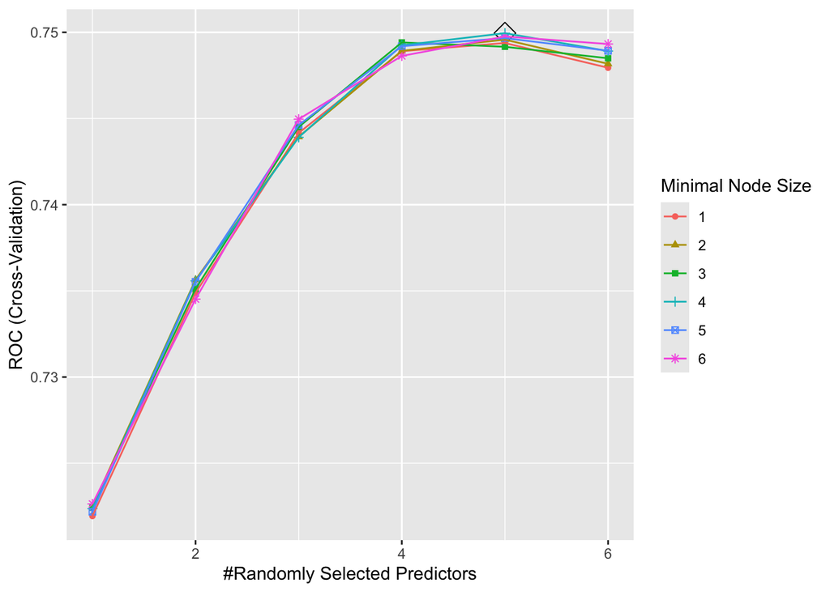

```r
# Model A
set.seed(2)

rf_A.grid <- expand.grid(
  mtry = 1:6,
  splitrule = "gini",
  min.node.size = 1:6
)

rf_A.fit <- train(
  high_risk ~ .,
  data = train_A,
  method = "ranger",
  tuneGrid = rf_A.grid,
  trControl = ctrl,
  metric = "ROC",
  importance = "permutation"
)

ggplot(rf_A.fit, highlight = TRUE)
```

```r
rf_A.fit$bestTune
```

```
##    mtry splitrule min.node.size
## 28    5      gini             4
```

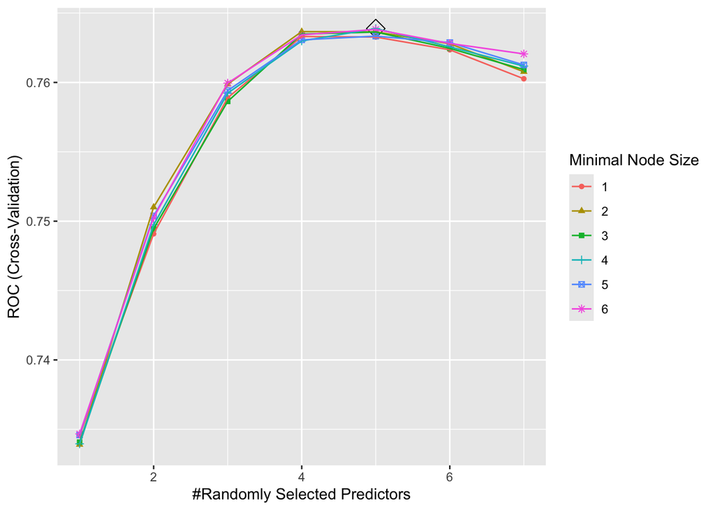

```r
# Model B
set.seed(2)

rf_B.grid <- expand.grid(
  mtry = 1:7,
  splitrule = "gini",
  min.node.size = 1:6
)

rf_B.fit <- train(
  high_risk ~ .,
  data = train_B,
  method = "ranger",
  tuneGrid = rf_B.grid,
  trControl = ctrl,
  metric = "ROC",
  importance = "permutation"
)

ggplot(rf_B.fit, highlight = TRUE)
```

```r
rf_B.fit$bestTune
```

```
##    mtry splitrule min.node.size
## 28    5      gini             4
```

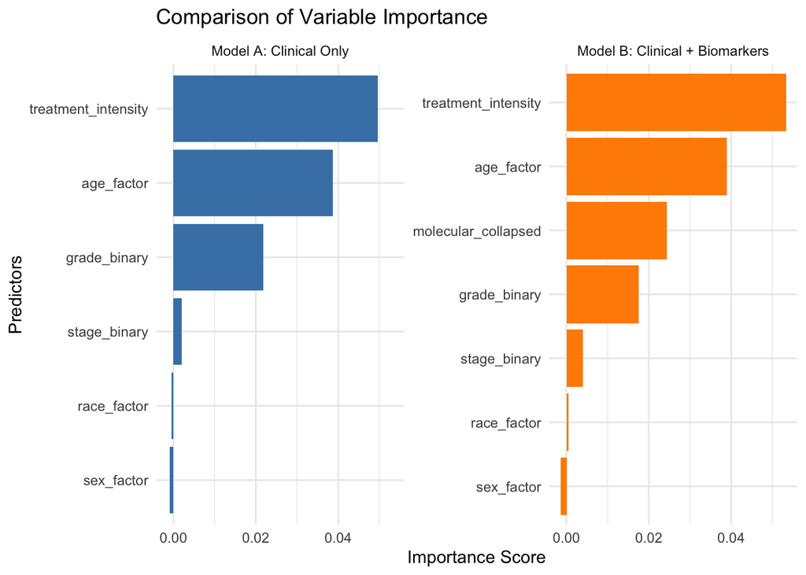

```r
# variable importance for Random Forest Model A
rf_A.final <- ranger(
  high_risk ~ .,
  data = train_A,
  mtry = rf_A.fit$bestTune$mtry,
  splitrule = "gini",
  min.node.size = rf_A.fit$bestTune$min.node.size,
  importance = "permutation",
  probability = TRUE
)

# variable importance for Random Forest Model B
rf_B.final <- ranger(
  high_risk ~ .,
  data = train_B,
  mtry = rf_B.fit$bestTune$mtry,
  splitrule = "gini",
  min.node.size = rf_B.fit$bestTune$min.node.size,
  importance = "permutation",
  probability = TRUE
)

# Extracting Variable importance for both models to plot them together
imp_A <- as.data.frame(ranger::importance(rf_A.final)) %>%
  rownames_to_column(var = "Variable") %>%
  rename(Importance = 2) %>%
  mutate(Model = "Model A: Clinical Only")

imp_B <- as.data.frame(ranger::importance(rf_B.final)) %>%
  rownames_to_column(var = "Variable") %>%
  rename(Importance = 2) %>%
  mutate(Model = "Model B: Clinical + Biomarkers")

combined_imp <- bind_rows(imp_A, imp_B)

# Creating faceted plot
ggplot(combined_imp, aes(x = reorder(Variable, Importance), y = Importance, fill = Model)) +
  geom_col(show.legend = FALSE) +
  coord_flip() +
  facet_wrap(~Model, scales = "free_y") +
  labs(
    title = "Comparison of Variable Importance",
    x = "Predictors",
    y = "Importance Score",
  ) +
  theme_minimal() +
  scale_fill_manual(values = c("steelblue", "darkorange"))
```

This plot shows the differences in variable importance between Model A and Model B. The results of model A clearly illustrates the importance of treatment intensity which has direct implications on survival and justifies its inclusion in the model as a summary measure of clinical interventions. Age, grade, and stage were among the other most important variables. Model B has a slightly different profile where the molecular biomarker variable is ranked third in importance above both grade and stage, indicating that it is a highly relevant predictor and contributed significantly to the model. The visualization is another piece of evidence that molecular biomarkers provide unique and substantial predictive value.

```r
## Evaluation on Training Data (Model A)

# Model A
rf_A_train_prob <- predict(rf_A.fit, newdata = train_A, type = "prob")[, "HighRisk"]
rf_A_train_pred <- predict(rf_A.fit, newdata = train_A)

# Training Confusion Matrix
confusionMatrix(rf_A_train_pred, train_A$high_risk)
```

```
## Confusion Matrix and Statistics
##
##           Reference
## Prediction HighRisk LowRisk
##   HighRisk     2112     774
##   LowRisk       581    1254
##
##                Accuracy : 0.713
##                  95% CI : (0.6998, 0.7259)
##     No Information Rate : 0.5704
##     P-Value [Acc > NIR] : < 2.2e-16
##
##                   Kappa : 0.4074
##
##  Mcnemar's Test P-Value : 1.829e-07
##
##             Sensitivity : 0.7843
##             Specificity : 0.6183
##          Pos Pred Value : 0.7318
##          Neg Pred Value : 0.6834
##              Prevalence : 0.5704
##          Detection Rate : 0.4474
##    Detection Prevalence : 0.6113
##       Balanced Accuracy : 0.7013
##
##        'Positive' Class : HighRisk
##
```

```r
# Training ROC/AUC
roc_rf_A_train  <- roc(train_A$high_risk, rf_A_train_prob)
roc_rf_A_train$auc
```

```
## Area under the curve: 0.7959
```

```r
## Evaluation on Training Data (Model B - with Biomarkers)
# Model B
rf_B_train_prob <- predict(rf_B.fit, newdata = train_B, type = "prob")[, "HighRisk"]
rf_B_train_pred <- predict(rf_B.fit, newdata = train_B)

# Training Confusion Matrix
confusionMatrix(rf_B_train_pred, train_B$high_risk)
```

```
## Confusion Matrix and Statistics
##
##           Reference
## Prediction HighRisk LowRisk
##   HighRisk     2222     839
##   LowRisk       471    1189
##
##                Accuracy : 0.7225
##                  95% CI : (0.7095, 0.7353)
##     No Information Rate : 0.5704
##     P-Value [Acc > NIR] : < 2.2e-16
##
##                   Kappa : 0.4208
##
##  Mcnemar's Test P-Value : < 2.2e-16
##
##             Sensitivity : 0.8251
##             Specificity : 0.5863
##          Pos Pred Value : 0.7259
##          Neg Pred Value : 0.7163
##              Prevalence : 0.5704
##          Detection Rate : 0.4707
##    Detection Prevalence : 0.6484
##       Balanced Accuracy : 0.7057
##
##        'Positive' Class : HighRisk
##
```

```r
# Training ROC/AUC
roc_rf_B_train  <- roc(train_B$high_risk, rf_B_train_prob)
roc_rf_B_train$auc
```

```
## Area under the curve: 0.817
```

### Algorithm 3 - Boosting

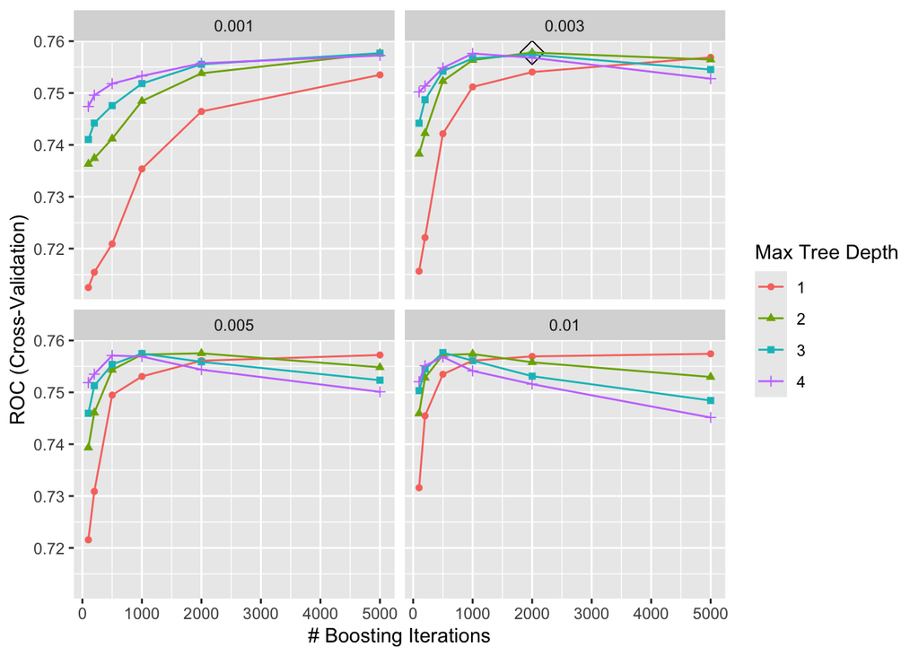

```r
set.seed(2)

gbm_A.grid <- expand.grid(
  n.trees = c(100, 200, 500, 1000, 2000, 5000),
  interaction.depth = 1:4,
  shrinkage = c(0.001, 0.003, 0.005, 0.01),
  n.minobsinnode = 10
)

# Model A
gbm_A.fit <- train(
  high_risk ~ .,
  data = train_A,
  method = "gbm",
  tuneGrid = gbm_A.grid,
  trControl = ctrl,
  distribution = "bernoulli",
  metric = "ROC",
  verbose = FALSE
)

ggplot(gbm_A.fit, highlight = TRUE)
```

```r
gbm_A.fit$bestTune
```

```
##    n.trees interaction.depth shrinkage n.minobsinnode
## 35    2000                 2     0.003             10
```

The tuning process for Model A identified an optimal tune of 2,000 trees with a shrinkage of 0.003 and an interaction depth of 2.

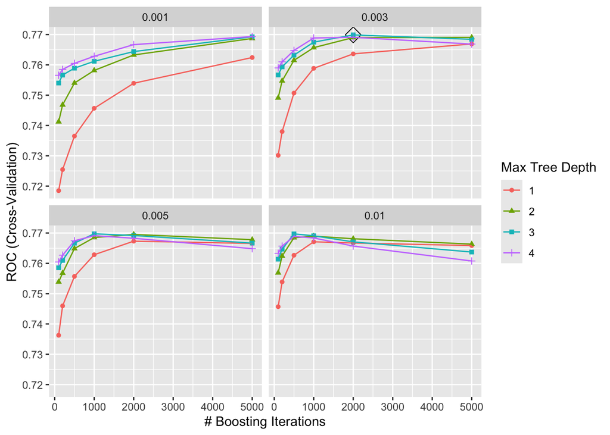

```r
# Model B
set.seed(2)

gbm_B.grid <- expand.grid(
  n.trees = c(100, 200, 500, 1000, 2000, 5000),
  interaction.depth = 1:4,
  shrinkage = c(0.001, 0.003, 0.005, 0.01),
  n.minobsinnode = 10
)

gbm_B.fit <- train(
  high_risk ~ .,
  data = train_B,
  method = "gbm",
  tuneGrid = gbm_B.grid,
  trControl = ctrl,
  distribution = "bernoulli",
  metric = "ROC",
  verbose = FALSE
)

ggplot(gbm_B.fit, highlight = TRUE)
```

```r
gbm_B.fit$bestTune
```

```
##    n.trees interaction.depth shrinkage n.minobsinnode
## 41    2000                 3     0.003             10
```

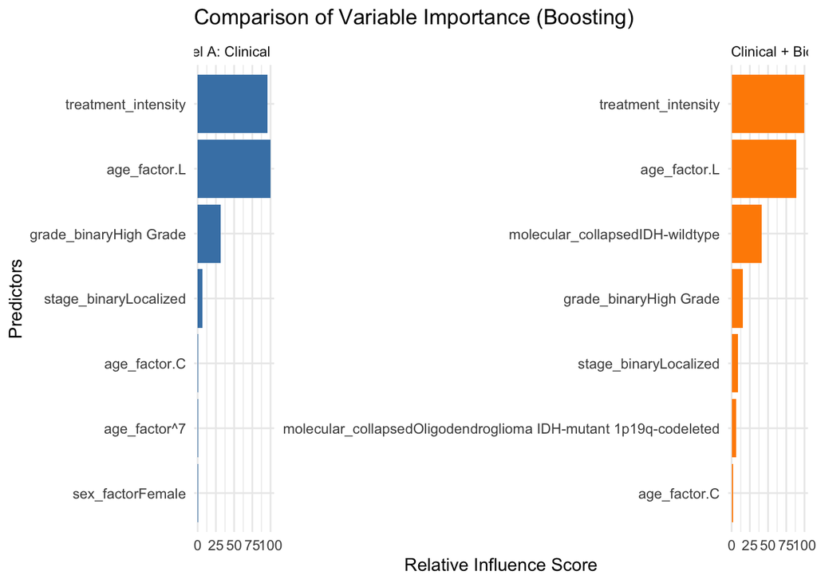

```r
# variable importance for Boosting Model A
imp_A_gbm <- caret::varImp(gbm_A.fit)$importance %>%
  rownames_to_column(var = "Variable") %>%
  rename(Importance = Overall) %>%
  mutate(Model = "Model A: Clinical Only") %>%
  slice_max(Importance, n = 7)

# variable importance for Boosting Model B
imp_B_gbm <- caret::varImp(gbm_B.fit)$importance %>%
  rownames_to_column(var = "Variable") %>%
  rename(Importance = Overall) %>%
  mutate(Model = "Model B: Clinical + Biomarkers") %>%
  slice_max(Importance, n = 7)

# Extracting Variable importance for both models to plot them together
combined_imp_gbm <- bind_rows(imp_A_gbm, imp_B_gbm)

# Creating faceted plot
ggplot(combined_imp_gbm, aes(x = reorder(Variable, Importance), y = Importance, fill = Model)) +
  geom_col(show.legend = FALSE) +
  coord_flip() +
  facet_wrap(~Model, scales = "free_y") +
  labs(
    title = "Comparison of Variable Importance (Boosting)",
    x = "Predictors",
    y = "Relative Influence Score",
  ) +
  theme_minimal() +
  scale_fill_manual(values = c("steelblue", "darkorange"))
```

This plot shows the variable importance of the boosting algorithm. For model A, age, treatment intensity nd a high grade were the most important predictors. In model B, age and treatment intensity are also the top 2 contributors but the third is a molecular biomarker (IDH-wildtype) predictor. This indicates that IDH-wildtype is a major predictor of being assessed as high-risk. This biomarker outranked both grade and stage in its contribution to predicting high-risk patients

```r
## Evaluation on Training Data (Model A)
gbm_A_train_prob <- predict(gbm_A.fit, newdata = train_A, type = "prob")[, "HighRisk"]
gbm_A_train_pred <- predict(gbm_A.fit, newdata = train_A)

# Training Confusion Matrix
confusionMatrix(gbm_A_train_pred, train_A$high_risk)
```

```
## Confusion Matrix and Statistics
##
##           Reference
## Prediction HighRisk LowRisk
##   HighRisk     1975     739
##   LowRisk       718    1289
##
##                Accuracy : 0.6914
##                  95% CI : (0.678, 0.7045)
##     No Information Rate : 0.5704
##     P-Value [Acc > NIR] : <2e-16
##
##                   Kappa : 0.3695
##
##  Mcnemar's Test P-Value : 0.6003
##
##             Sensitivity : 0.7334
##             Specificity : 0.6356
##          Pos Pred Value : 0.7277
##          Neg Pred Value : 0.6423
##              Prevalence : 0.5704
##          Detection Rate : 0.4183
##    Detection Prevalence : 0.5749
##       Balanced Accuracy : 0.6845
##
##        'Positive' Class : HighRisk
##
```

```r
# Training ROC/AUC
roc_gbm_A_train <- roc(train_A$high_risk, gbm_A_train_prob)
roc_gbm_A_train$auc
```

```
## Area under the curve: 0.7642
```

```r
## Evaluation on Training Data (Model B - WITH Biomarkers)
gbm_B_train_prob <- predict(gbm_B.fit, newdata = train_B, type = "prob")[, "HighRisk"]
gbm_B_train_pred <- predict(gbm_B.fit, newdata = train_B)

# Training Confusion Matrix
confusionMatrix(gbm_B_train_pred, train_B$high_risk)
```

```
## Confusion Matrix and Statistics
##
##           Reference
## Prediction HighRisk LowRisk
##   HighRisk     1996     719
##   LowRisk       697    1309
##
##                Accuracy : 0.7001
##                  95% CI : (0.6868, 0.7131)
##     No Information Rate : 0.5704
##     P-Value [Acc > NIR] : <2e-16
##
##                   Kappa : 0.3872
##
##  Mcnemar's Test P-Value : 0.5768
##
##             Sensitivity : 0.7412
##             Specificity : 0.6455
##          Pos Pred Value : 0.7352
##          Neg Pred Value : 0.6525
##              Prevalence : 0.5704
##          Detection Rate : 0.4228
##    Detection Prevalence : 0.5751
##       Balanced Accuracy : 0.6933
##
##        'Positive' Class : HighRisk
##
```

```r
# Training ROC/AUC
roc_gbm_B_train <- roc(train_B$high_risk, gbm_B_train_prob)
roc_gbm_B_train$auc
```

```
## Area under the curve: 0.7787
```

Model A Performance Metrics: $AUC = 0.764$ $Sensitivity = 0.733$  
$Specificity = 0.636$

Similar to the above algorithms, Model B outperformed Model A in AUC but the AUC for model B was lower than in the Random Forest model. However, in comparison to the above models where model B had a worse Specificity, with boosting, Model B has a higher performance for all three metrics (AUC, Sensitivity and Specificity).

### Summary of Model compairison

```r
# Function to extract metrics for a given fit and its training data
get_metrics <- function(fit, data, approach, model_type) {
  # Get predictions
  prob <- predict(fit, newdata = data, type = "prob")[, "HighRisk"]
  pred <- predict(fit, newdata = data)

  # Calculate Metrics
  cm <- confusionMatrix(pred, data$high_risk)
  auc_val <- roc(data$high_risk, prob, quiet = TRUE)$auc

  # Return data frame row
  data.frame(
    Approach = approach,
    Model = model_type,
    Training_AUC = as.numeric(auc_val),
    Sensitivity = as.numeric(cm$byClass["Sensitivity"]),
    Specificity = as.numeric(cm$byClass["Specificity"])
  )
}

# Creating Master Table
internal_validation_summary <- bind_rows(
  get_metrics(en_A.fit, train_A, "Elastic Net", "Model A: Clinical Only"),
  get_metrics(en_B.fit, train_B, "Elastic Net", "Model B: Clinical + Biomarkers"),
  get_metrics(rf_A.fit, train_A, "Random Forest", "Model A: Clinical Only"),
  get_metrics(rf_B.fit, train_B, "Random Forest", "Model B: Clinical + Biomarkers"),
  get_metrics(gbm_A.fit, train_A, "Boosting", "Model A: Clinical Only"),
  get_metrics(gbm_B.fit, train_B, "Boosting", "Model B: Clinical + Biomarkers")
)

# View the table
internal_validation_summary %>%
  mutate(across(where(is.numeric), ~ round(.x, 4))) %>%
  knitr::kable(caption = "Internal Validation: Training Set Performance Across All Architectures")
```

Internal Validation: Training Set Performance Across All Architectures

| Approach | Model | Training_AUC | Sensitivity | Specificity |
| --- | --- | --- | --- | --- |
| Elastic Net | Model A: Clinical Only | 0.7601 | 0.7620 | 0.5971 |
| Elastic Net | Model B: Clinical + Biomarkers | 0.7694 | 0.8084 | 0.5449 |
| Random Forest | Model A: Clinical Only | 0.7959 | 0.7843 | 0.6183 |
| Random Forest | Model B: Clinical + Biomarkers | 0.8170 | 0.8251 | 0.5863 |
| Boosting | Model A: Clinical Only | 0.7642 | 0.7334 | 0.6356 |
| Boosting | Model B: Clinical + Biomarkers | 0.7787 | 0.7412 | 0.6455 |

Based on this internal comparison, the Random Forest algorithm performed the best as it had the highest AUC for both Model A & B. While Boosting had a more balanced Sensitivity and Specificity, the lower AUC and sensitivity across the board makes it weaker from a clinical perspective where missing true positives can be extremely consequential.

## Final Test Set Evaluation: Random Forest Model on Test Set

```r
# Generating Test Predictions and Confusion Matrices
rf_A_test_prob <- predict(rf_A.fit, newdata = test_A, type = "prob")[, "HighRisk"]
rf_A_test_pred <- predict(rf_A.fit, newdata = test_A)
cm_rf_A <- confusionMatrix(rf_A_test_pred, test_A$high_risk)

rf_B_test_prob <- predict(rf_B.fit, newdata = test_B, type = "prob")[, "HighRisk"]
rf_B_test_pred <- predict(rf_B.fit, newdata = test_B)
cm_rf_B <- confusionMatrix(rf_B_test_pred, test_B$high_risk)

roc_rf_A_test <- roc(test_A$high_risk, rf_A_test_prob, quiet = TRUE)
roc_rf_B_test <- roc(test_B$high_risk, rf_B_test_prob, quiet = TRUE)


final_rf_test_results <- data.frame(
  Model = c("Model A: Clinical Only", "Model B: Clinical + Biomarkers"),
  Test_AUC = c(as.numeric(roc_rf_A_test$auc), as.numeric(roc_rf_B_test$auc)),
  Sensitivity = c(cm_rf_A$byClass["Sensitivity"], cm_rf_B$byClass["Sensitivity"]),
  Specificity = c(cm_rf_A$byClass["Specificity"], cm_rf_B$byClass["Specificity"]),
  Test_Error = c(mean(rf_A_test_pred != test_A$high_risk), mean(rf_B_test_pred != test_B$high_risk))
)

final_rf_test_results %>%
  mutate(across(where(is.numeric), ~ round(.x, 4))) %>%
  knitr::kable(caption = "Final Results: Random Forest Performance on Test Set")
```

Final Results: Random Forest Performance on Test Set

| Model | Test_AUC | Sensitivity | Specificity | Test_Error |
| --- | --- | --- | --- | --- |
| Model A: Clinical Only | 0.7557 | 0.7404 | 0.5759 | 0.3302 |
| Model B: Clinical + Biomarkers | 0.7473 | 0.7923 | 0.5385 | 0.3167 |

## Plotting ROC curve for Model A and Model B comparison on Test Set using Random Forest

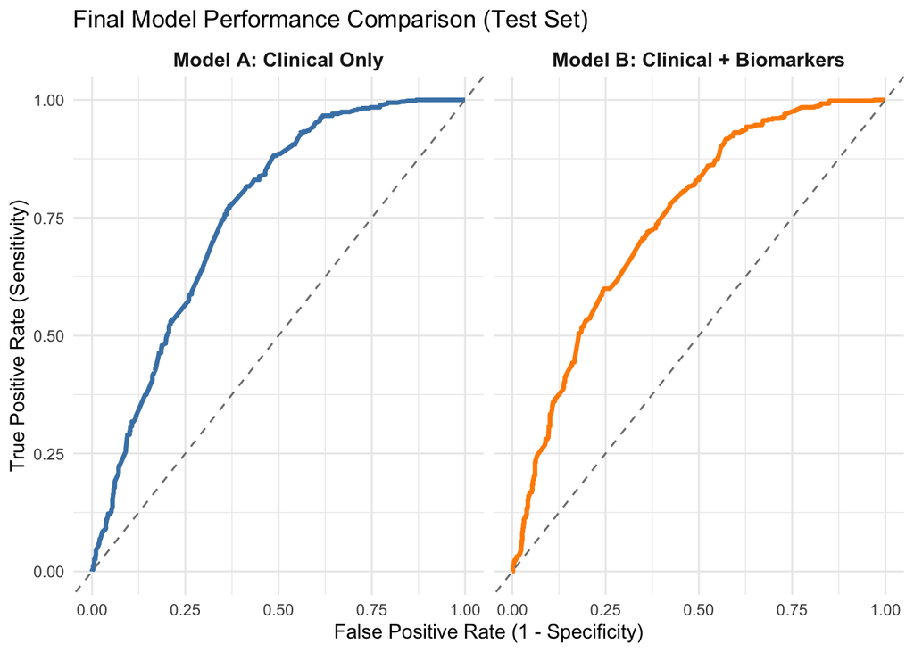

```r
roc_list <- list("Model A: Clinical Only" = roc_rf_A_test,
                 "Model B: Clinical + Biomarkers" = roc_rf_B_test)

ggroc(roc_list, legacy.axes = TRUE, size = 1.2) +
  facet_wrap(~name) +
  geom_abline(slope = 1, intercept = 0, linetype = "dashed", color = "grey50") +
  scale_color_manual(values = c("steelblue", "darkorange")) +
  theme_minimal() +
  labs(title = "Final Model Performance Comparison (Test Set)",
       x = "False Positive Rate (1 - Specificity)",
       y = "True Positive Rate (Sensitivity)",
       color = "Model Version") +
  theme(legend.position = "none",
        strip.text = element_text(face = "bold", size = 11))
```

The final evaluation results differed from the previous comparisons between Model A & Model B. While Model B outperformed Model A in internal validations, Model A achieved a higher AUC on the test set for Random Forest. This suggests overfitting from the molecular biomarkers to the training data. However, Model B did exhibit a higher sensitivity, suggesting that Model B is better at predicting true positives. In a clinical setting, this increased capacity to identify high-risk patients is an advantage over model A. The ROC curve was plotted for Random Forest to illustrate the balance between sensitivity and specificity of a non-linear model that allows for complex interactions between features.

### Limitations & Ethical Considerations

While our models generally showed that incorporating molecular biomarkers improves predictive power, several limitations and ethical considerations should be noted. A main limitation is the inclusion of the Treatment Intensity Index, which may introduce post-treatment bias. While treatment intensity is a strong predictor of survival, it is also informed by diagnosis and molecular profile. We chose to retain this variable to maximize the model’s accuracy, while acknowledging that it may partially mediate the relationship between molecular biomarkers and 1-year mortality. Additionally, brain cancer is a particularly rare outcome in the grande scheme of all cancer diagnoses and with short term availability of biomarker data (2018 and onward), the sample size is relatively small leading to the possibility of overfitting to our specific cohort. This may have implications on the generalizability of these models.

The primary ethical concern arises from the risk of applying an imperfect model in a clinical setting with very high-stakes. As is, the performance metrics are still too low to be used confidently in a real world setting for such a deadly disease.Having false negatives in such a high stakes assessment of risk is extremely dangerous. Brain cancers develop rapidly and a delay in treatment due to the model missing a high-risk case could have serious implications. False positives are also harmful and may cause the patient and their family extreme stress. Another issue is that the treatment intensity index created may be subject to confounding by socioeconomic status since treatment is typically tied to insurance and income. This would likely negatively impact the models performance in lower-income populations.

### Conclusion

In conclusion, the models with molecular biomarkers outperformed those without for every algorithm assessed internally. However, when exposed to the testing set, the opposite occured likely due to overfitting to the training set. This analysis demonstrated that the inclusion of molecular biomarkers improves the sensitivity of model prediction in identifying high-risk patients but the models did not have strong generalizability. Future research should explore the addition of more variables to improve model performance and strengthen our ability to consistently predict high-risk patients. Studies should also run subgroup analyses to evaluate how these models perform on various underserved populations.